# Homework 8: Data Exploration

Matt Futia

3/31/2021

### Study background

Investigating the correlation between *Mysis diluviana* density in benthic habitats and time of day

- *M. diluviana* are known to have a diel vertical migration in which individuals remain at the bottom during the day (predator avoidance) and many but not all migrate into the water column during the night to feed.
- For this fake data set, samples will have been collected from the bottom across six times during a 24 hour period (01:00, 05:00, 09:00, 13:00, 17:00, 21:00). This process was repeated across 40 times during the summer season. Samples were collected with 10 minute benthic sled tows.
- The number of individuals collected at each time period on each day were recorded.

### Generate practice data

```r
set.seed(123) # only included for showing significance after running the model multiple times for later comparisons
t01 <- rnorm(n=40,mean=180, sd = 40)
t05 <- rnorm(n=40,mean=210, sd = 60)
t09 <- rnorm(n=40,mean=440, sd = 50)
t13 <- rnorm(n=40,mean=500, sd = 30)
t17 <- rnorm(n=40,mean=470, sd = 60)
t21 <- rnorm(n=40,mean=280, sd = 80)

total <- data.frame(t01,t05,t09,t13,t17,t21)
total$id <- 1:nrow(total)

total_long <- melt(total, id.vars="id")
colnames(total_long) <- c("id", "time", "density")
```

Sampling methods and results (mean and standard deviation) were derived from methods and densities described in published studies. Standard deviation values were estimated based on summer diurnal light cycles and hypothesized migration timing of *M. diluviana*.

### Compare *M. diluviana* density across times with ANOVA

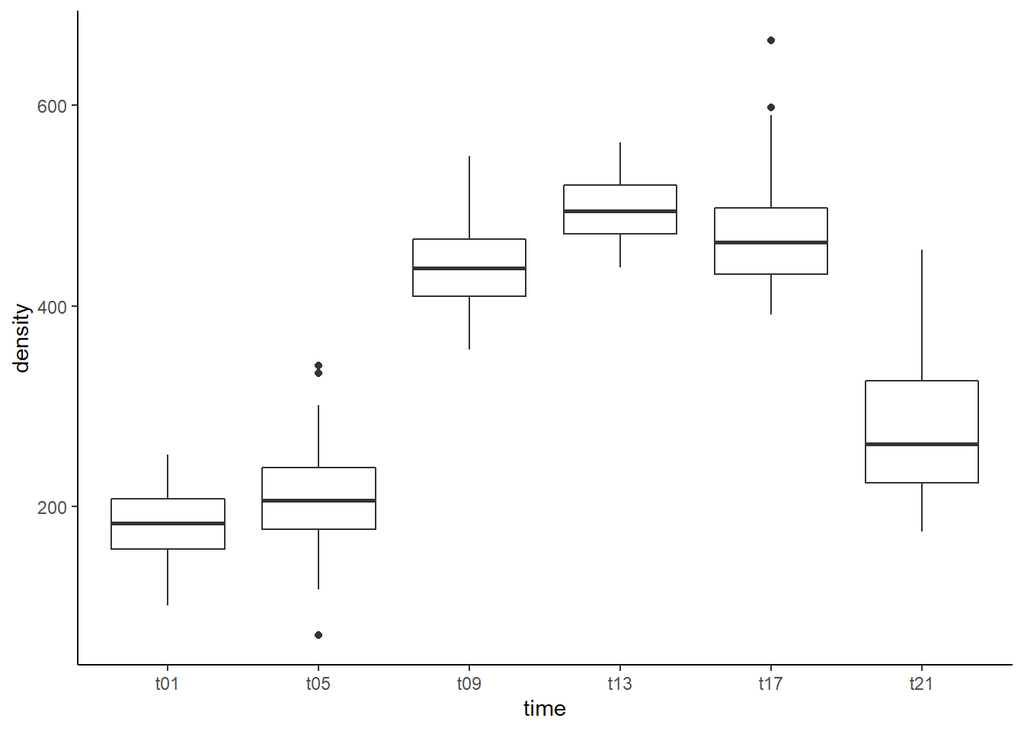

```r
p1 <- ggplot(total_long, aes(time, density))+
  geom_boxplot()+
  theme_classic()
p1
```

```r
test <- aov(density~time, total_long)
summary(test)
```

```
##              Df  Sum Sq Mean Sq F value Pr(>F)
## time          5 3883594  776719     284 <2e-16 ***
## Residuals   234  640042    2735
## ---
## Signif. codes:  0 '***' 0.001 '**' 0.01 '*' 0.05 '.' 0.1 ' ' 1
```

```r
TukeyHSD(test, group = T)
```

```
##   Tukey multiple comparisons of means
##     95% family-wise confidence level
##
## Fit: aov(formula = density ~ time, data = total_long)
##
## $time
##               diff         lwr         upr     p adj
## t05-t01   27.78971   -5.814261   61.393685 0.1688924
## t09-t01  258.58552  224.981551  292.189496 0.0000000
## t13-t01  315.01738  281.413412  348.621358 0.0000000
## t17-t01  289.19263  255.588654  322.796599 0.0000000
## t21-t01   99.03837   65.434398  132.642343 0.0000000
## t09-t05  230.79581  197.191839  264.399784 0.0000000
## t13-t05  287.22767  253.623700  320.831646 0.0000000
## t17-t05  261.40291  227.798942  295.006887 0.0000000
## t21-t05   71.24866   37.644685  104.852631 0.0000001
## t13-t09   56.43186   22.827889   90.035834 0.0000369
## t17-t09   30.60710   -2.996870   64.211075 0.0971584
## t21-t09 -159.54715 -193.151126 -125.943181 0.0000000
## t17-t13  -25.82476  -59.428731    7.779214 0.2378646
## t21-t13 -215.97901 -249.582987 -182.375042 0.0000000
## t21-t17 -190.15426 -223.758229 -156.550283 0.0000000
```

Running the model multiple times with the same conditions (i.e., mean, sample size, and standard deviation) demonstrated three general groups with significant differences (p < 0.05) in *M. diluviana* density. A low density grouping included the t01 and t05 samples, an intermediate density included t21, and a high density group included t09, t13, and t17. However, significance among times within the low and high density groups was inconsistent across repeated models and, similarly, the intermediate density time (t21) occasionally had no significant difference from the t05 sample from the low density group.

#### Plot with significance (for fixed data)

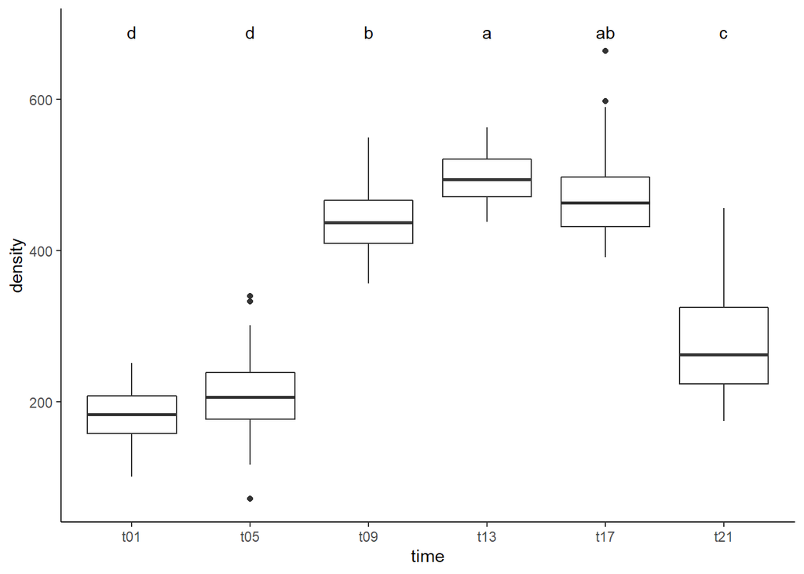

```r
sig <- c("d","d","b","a","ab","c")

p2 <- p1 +
  annotate(geom = "text",
           x = unique(total_long$time),y = max(total_long$density)+25,
           label = sig)

p2
```

#### Re-run practice data with adjusted means

```r
# adjust mean values within groups to a difference between 10 and 50
t01_m <- rnorm(n=40,mean=190, sd = 40)
t05_m <- rnorm(n=40,mean=200, sd = 60) # difference in density of 10 from t01 and 50 from t21
t09_m <- rnorm(n=40,mean=450, sd = 50) # difference in density of 40 from t13 and 10 from t17
t13_m <- rnorm(n=40,mean=490, sd = 30) # difference in density of 30 from t17
t17_m <- rnorm(n=40,mean=460, sd = 60)
t21_m <- rnorm(n=40,mean=250, sd = 80)

total_m <- data.frame(t01_m,t05_m,t09_m,t13_m,t17_m,t21_m)
total_m$id <- 1:nrow(total_m)

total_long_m <- melt(total_m, id.vars="id")
colnames(total_long_m) <- c("id", "time", "density")

test_m <- aov(density~time, total_long_m)
summary(test_m)
```

```
##              Df  Sum Sq Mean Sq F value Pr(>F)
## time          5 3705733  741147   222.9 <2e-16 ***
## Residuals   234  778117    3325
## ---
## Signif. codes:  0 '***' 0.001 '**' 0.01 '*' 0.05 '.' 0.1 ' ' 1
```

```r
TukeyHSD(test_m)
```

```
##   Tukey multiple comparisons of means
##     95% family-wise confidence level
##
## Fit: aov(formula = density ~ time, data = total_long_m)
##
## $time
##                   diff         lwr         upr     p adj
## t05_m-t01_m   16.95310  -20.098667   54.004861 0.7766673
## t09_m-t01_m  255.67413  218.622370  292.725897 0.0000000
## t13_m-t01_m  294.50429  257.452528  331.556056 0.0000000
## t17_m-t01_m  266.11382  229.062056  303.165584 0.0000000
## t21_m-t01_m   66.86811   29.816343  103.919870 0.0000069
## t09_m-t05_m  238.72104  201.669272  275.772800 0.0000000
## t13_m-t05_m  277.55120  240.499431  314.602959 0.0000000
## t17_m-t05_m  249.16072  212.108959  286.212486 0.0000000
## t21_m-t05_m   49.91501   12.863246   86.966773 0.0019333
## t13_m-t09_m   38.83016    1.778395   75.881923 0.0339050
## t17_m-t09_m   10.43969  -26.612077   47.491450 0.9655622
## t21_m-t09_m -188.80603 -225.857790 -151.754263 0.0000000
## t17_m-t13_m  -28.39047  -65.442236    8.661291 0.2408637
## t21_m-t13_m -227.63619 -264.687949 -190.584422 0.0000000
## t21_m-t17_m -199.24571 -236.297477 -162.193949 0.0000000
```

Decreasing the difference among mean values within group to 10 eliminated significant differences within density groups. Differences in density of 30 and 40 had inconsistent statistical significance, although density differences of 30 were significant less frequently than differences of 40. Lastly, differences in density of 50 always had significant differences. These results, however, are also influenced by the differences in standard deviation of among sampling events.

#### Re-run practice data with adjusted sample size

```r
# 50% sample effort
t01_n20 <- rnorm(n=20,mean=180, sd = 40)
t05_n20 <- rnorm(n=20,mean=210, sd = 60)
t09_n20 <- rnorm(n=20,mean=440, sd = 50)
t13_n20 <- rnorm(n=20,mean=500, sd = 30)
t17_n20 <- rnorm(n=20,mean=470, sd = 60)
t21_n20 <- rnorm(n=20,mean=280, sd = 80)

total_n20 <- data.frame(t01_n20,t05_n20,t09_n20,t13_n20,t17_n20,t21_n20)
total_n20$id <- 1:nrow(total_n20)

total_long_n20 <- melt(total_n20, id.vars="id")
colnames(total_long_n20) <- c("id", "time", "density")

test_n20 <- aov(density~time, total_long_n20)
summary(test_n20)
```

```
##              Df  Sum Sq Mean Sq F value Pr(>F)
## time          5 2110366  422073   150.6 <2e-16 ***
## Residuals   114  319524    2803
## ---
## Signif. codes:  0 '***' 0.001 '**' 0.01 '*' 0.05 '.' 0.1 ' ' 1
```

```r
TukeyHSD(test_n20)
```

```
##   Tukey multiple comparisons of means
##     95% family-wise confidence level
##
## Fit: aov(formula = density ~ time, data = total_long_n20)
##
## $time
##                        diff         lwr        upr     p adj
## t05_n20-t01_n20    2.683528  -45.846931   51.21399 0.9999849
## t09_n20-t01_n20  261.816186  213.285728  310.34664 0.0000000
## t13_n20-t01_n20  312.238127  263.707668  360.76859 0.0000000
## t17_n20-t01_n20  276.765953  228.235494  325.29641 0.0000000
## t21_n20-t01_n20   69.319854   20.789395  117.85031 0.0009253
## t09_n20-t05_n20  259.132658  210.602200  307.66312 0.0000000
## t13_n20-t05_n20  309.554599  261.024140  358.08506 0.0000000
## t17_n20-t05_n20  274.082425  225.551966  322.61288 0.0000000
## t21_n20-t05_n20   66.636326   18.105868  115.16678 0.0016594
## t13_n20-t09_n20   50.421941    1.891482   98.95240 0.0367898
## t17_n20-t09_n20   14.949766  -33.580692   63.48023 0.9474889
## t21_n20-t09_n20 -192.496332 -241.026791 -143.96587 0.0000000
## t17_n20-t13_n20  -35.472174  -84.002633   13.05828 0.2851362
## t21_n20-t13_n20 -242.918273 -291.448731 -194.38781 0.0000000
## t21_n20-t17_n20 -207.446099 -255.976557 -158.91564 0.0000000
```

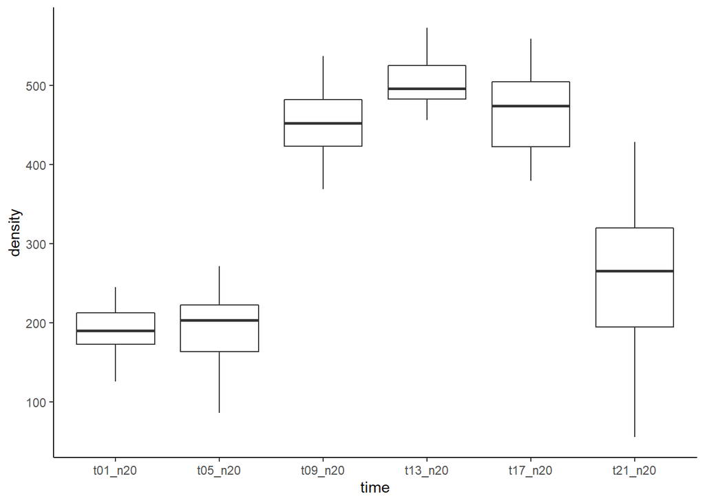

```r
ggplot(total_long_n20, aes(time, density))+
  geom_boxplot()+
  theme_classic()
```

```r
# 200% sample effort
t01_n80 <- rnorm(n=80,mean=180, sd = 40)
t05_n80 <- rnorm(n=80,mean=210, sd = 60)
t09_n80 <- rnorm(n=80,mean=440, sd = 50)
t13_n80 <- rnorm(n=80,mean=500, sd = 30)
t17_n80 <- rnorm(n=80,mean=470, sd = 60)
t21_n80 <- rnorm(n=80,mean=280, sd = 80)

total_n80 <- data.frame(t01_n80,t05_n80,t09_n80,t13_n80,t17_n80,t21_n80)
total_n80$id <- 1:nrow(total_n80)

total_long_n80 <- melt(total_n80, id.vars="id")
colnames(total_long_n80) <- c("id", "time", "density")

test_n80 <- aov(density~time, total_long_n80)
summary(test_n80)
```

```
##              Df  Sum Sq Mean Sq F value Pr(>F)
## time          5 7821277 1564255   488.7 <2e-16 ***
## Residuals   474 1517312    3201
## ---
## Signif. codes:  0 '***' 0.001 '**' 0.01 '*' 0.05 '.' 0.1 ' ' 1
```

```r
TukeyHSD(test_n80)
```

```
##   Tukey multiple comparisons of means
##     95% family-wise confidence level
##
## Fit: aov(formula = density ~ time, data = total_long_n80)
##
## $time
##                       diff         lwr        upr     p adj
## t05_n80-t01_n80   41.99588   16.398273   67.59349 0.0000513
## t09_n80-t01_n80  262.90296  237.305358  288.50057 0.0000000
## t13_n80-t01_n80  332.97622  307.378611  358.57382 0.0000000
## t17_n80-t01_n80  290.89239  265.294783  316.49000 0.0000000
## t21_n80-t01_n80  117.21508   91.617475  142.81269 0.0000000
## t09_n80-t05_n80  220.90709  195.309479  246.50469 0.0000000
## t13_n80-t05_n80  290.98034  265.382732  316.57794 0.0000000
## t17_n80-t05_n80  248.89651  223.298904  274.49412 0.0000000
## t21_n80-t05_n80   75.21920   49.621595  100.81681 0.0000000
## t13_n80-t09_n80   70.07325   44.475646   95.67086 0.0000000
## t17_n80-t09_n80   27.98943    2.391819   53.58703 0.0228099
## t21_n80-t09_n80 -145.68788 -171.285490 -120.09028 0.0000000
## t17_n80-t13_n80  -42.08383  -67.681434  -16.48622 0.0000490
## t21_n80-t13_n80 -215.76114 -241.358743 -190.16353 0.0000000
## t21_n80-t17_n80 -173.67731 -199.274915 -148.07970 0.0000000
```

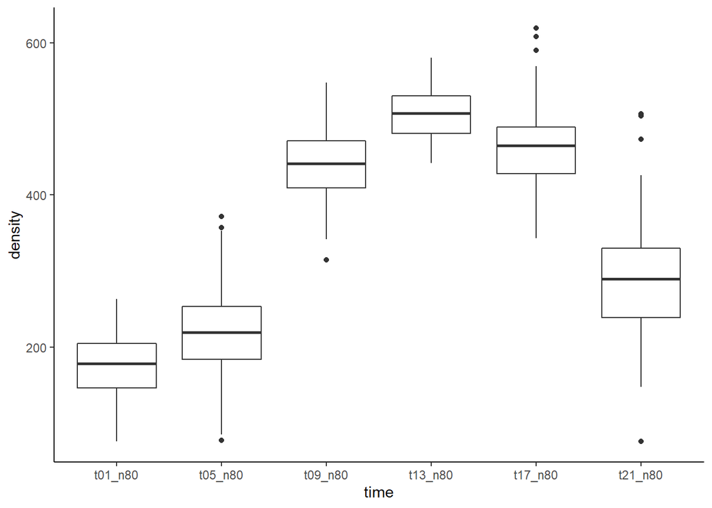

```r
ggplot(total_long_n80, aes(time, density))+
  geom_boxplot()+
  theme_classic()
```

While lowering sample size made statistical differences among sample densities less consistent (i.e., differences in densities within groups were more variable), doubling the sampling effort increased significance (i.e., lower p-value) resulting in more frequent statistical differences in density.